# Reproducible Research Project 1 Report

Lydia

1/2/2022

# Loading and Preprocessing the Data

**1. Load the data (i.e. read.csv())**

**2. Process/transform the data (if necessary) into a format suitable for your analysis**

```r
library(tidyverse)
library(ggplot2)
library(dplyr)

#Read in dataset
activity <- read.csv('activity.csv')

#Convert date column to date type
activity$date <- as.Date(activity$date)
```

# Mean Number of Steps per Day

**1. Calculate the total number of steps taken per day**

**2. If you do not understand the difference between a histogram and a barplot, research the difference between them. Make a histogram of the total number of steps taken each day**

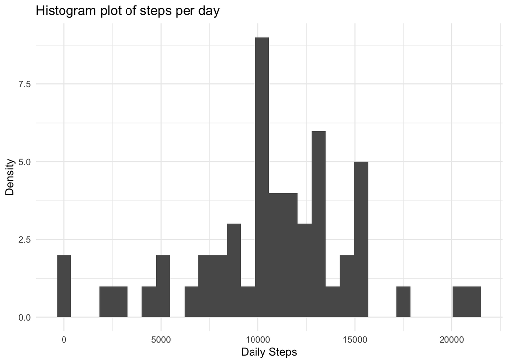

```r
#Summarise total steps per day
activity_day <- activity %>%
  group_by(date) %>%
  summarise(steps_day = sum(steps))

# Plot steps per day in histogram
steps_day_hist <-ggplot(activity_day, aes(x=steps_day)) +
  geom_histogram() +
  labs(title= "Histogram plot of steps per day",x="Daily Steps", y = "Density") +
  theme_minimal()

steps_day_hist
```

**3. Calculate and report the mean and median of the total number of steps taken per day**

```r
# Calculate mean and median steps per day
mean(activity_day$steps_day, na.rm = TRUE)
```

```
## [1] 10766.19
```

```r
median(activity_day$steps_day, na.rm = TRUE)
```

```
## [1] 10765
```

# Average Daily Activity Pattern

**1. Make a time series plot (i.e. type = “l”) of the 5-minute interval (x-axis) and the average number of steps taken, averaged across all days (y-axis)**

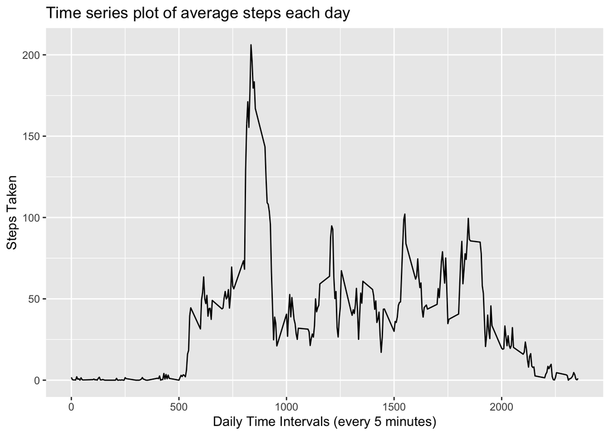

```r
#Plot average steps per time interval
ggplot(activity, aes(x = interval, y = steps)) +
  geom_line(stat = "summary", fun = "mean") +
  labs(title= "Time series plot of average steps each day",x="Daily Time Intervals (every 5 minutes)", y = "Steps Taken")
```

```r
#Create df of averages per interval
activity_avg_interval <- activity %>%
  group_by(interval) %>%
  summarise(steps = mean(steps, na.rm = TRUE ))
```

**2. Which 5-minute interval, on average across all the days in the dataset, contains the maximum number of steps?**

```r
activity_avg_interval[which.max(activity_avg_interval$steps),]
```

```
## # A tibble: 1 x 2
##   interval steps
##      <int> <dbl>
## 1      835  206.
```

# Imputing Missing Values

**1. Calculate and report the total number of missing values in the dataset (i.e. the total number of rows with NAs)**

```r
#Calculate number of missing values
sum(is.na(activity$steps))
```

```
## [1] 2304
```

**2. Devise a strategy for filling in all of the missing values in the dataset. The strategy does not need to be sophisticated. For example, you could use the mean/median for that day, or the mean for that 5-minute interval, etc.**

There are 2304 missing values for steps. Now, we will fill in those missing values, using the mean for the specific time interval across all days.

**3. Create a new dataset that is equal to the original dataset but with the missing data filled in.**

```r
#Create data set with actual and average steps per interval
activity_new <- left_join(activity, activity_avg_interval, by = 'interval', suffix = c("", "_avg"))

# Replace NAs in actual 'steps' with average if NA, otherwise keep value
activity_new$steps <- ifelse(is.na(activity_new$steps), activity_new$steps_avg, activity_new$steps)
```

**4. Make a histogram of the total number of steps taken each day and calculate and report the mean and median total number of steps taken per day. Do these values differ from the estimates from the first part of the assignment? What is the impact of imputing missing data on the estimates of the total daily number of steps?**

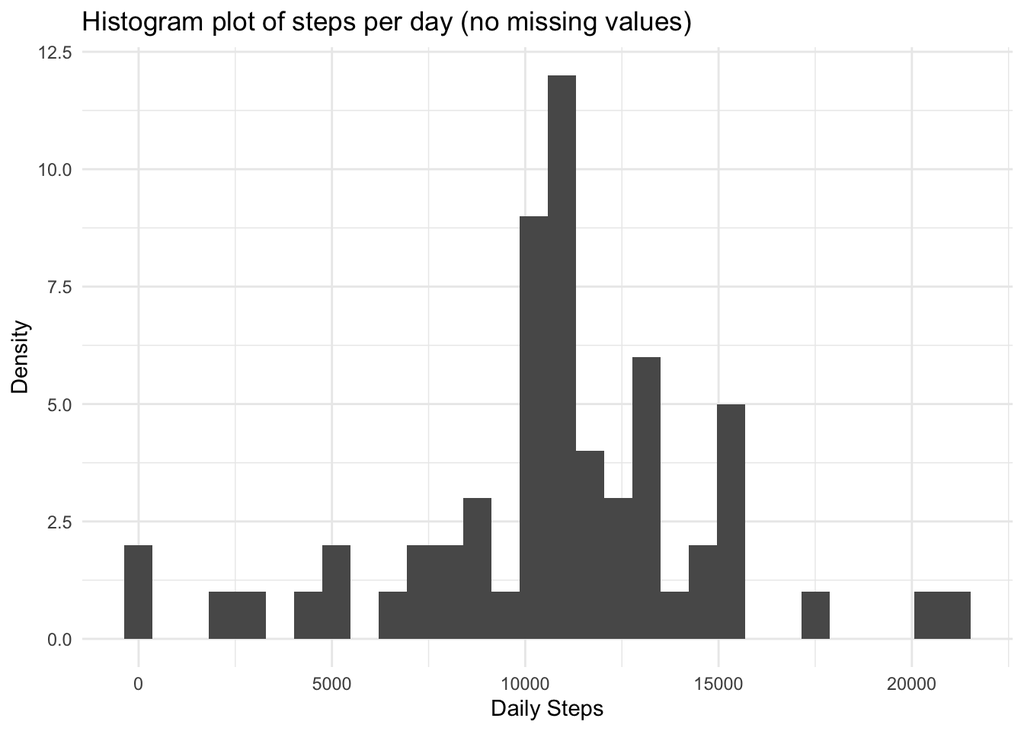

```r
#Summarise steps by day
activity_day_new <- activity_new %>%
  group_by(date) %>%
  summarise(steps_day = sum(steps))

# Plot steps per day in histogram
steps_day_hist_new <-ggplot(activity_day_new, aes(x=steps_day)) +
  geom_histogram() +
  labs(title= "Histogram plot of steps per day (no missing values)",x="Daily Steps", y = "Density") +
  theme_minimal()

steps_day_hist_new
```

```r
# Calculate mean and median steps per day
mean(activity_day_new$steps_day)
```

```
## [1] 10766.19
```

```r
median(activity_day_new$steps_day)
```

```
## [1] 10766.19
```

After imputing missing values, the mean number of daily steps did not change, but the median increased slightly from 10765 to 10766.19. Adding these missing values increased daily steps, but very slightly. In general, the data looks approximately the same.

# Differences in Activity Patterns between Weekdays and Weekends

**1. Create a new factor variable in the dataset with two levels – “weekday” and “weekend” indicating whether a given date is a weekday or weekend day.**

```r
#Create column that has day of week
activity_new$weekday <- weekdays(activity_new$date)

# Create column code that says whether date is weekday or weekend
activity_new$weekday_code <- ifelse(grepl("Saturday|Sunday", activity_new$weekday), "Weekend", "Weekday")
```

**2. Make a panel plot containing a time series plot (i.e. type = “l”) of the 5-minute interval (x-axis) and the average number of steps taken, averaged across all weekday days or weekend days (y-axis). See the README file in the GitHub repository to see an example of what this plot should look like using simulated data.**

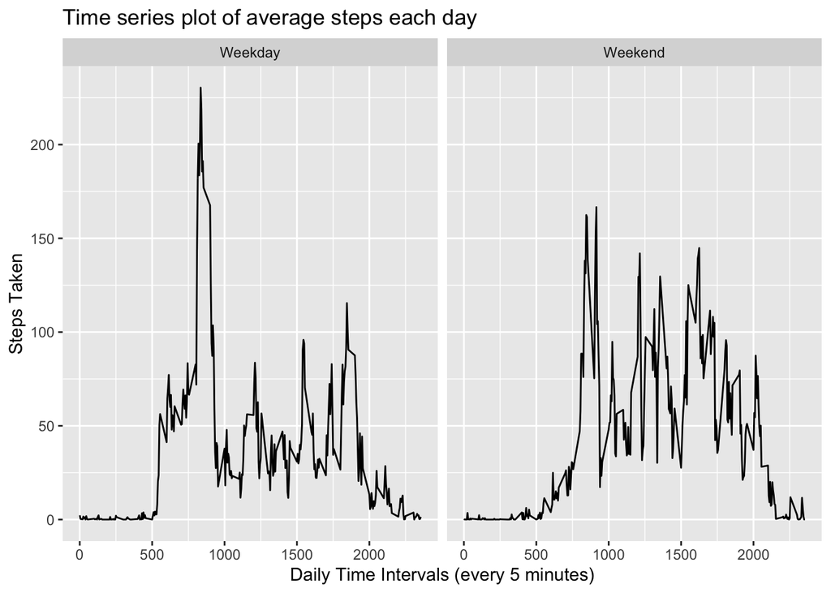

```r
#Plot average steps per time interval
ggplot(activity_new, aes(x = interval, y = steps)) +
  geom_line(stat = "summary", fun = "mean") +
  labs(title= "Time series plot of average steps each day",x="Daily Time Intervals (every 5 minutes)", y = "Steps Taken") +
  facet_wrap(~ weekday_code)
```